# Lab 01: Interrupted Time Series

PAF 512 - Advanced Regression

Lab Solutions

## AI & Coding Policy

- **Responsible AI Use:** Use AI to *support* your learning (debugging, explaining), not to *replace* it. Submitting code or answers generated by AI is not permitted.
- **Course Methods Required:** Please solve these problems using the specific R techniques taught in this module. AI may suggest shortcuts or different packages; avoid using these, as work relying on methodologies not found in the course materials will result in a loss of credit.

## Instructions

There are **4 sets of questions** to be answered. You can earn up to **100 points + 10 bonus points**. Points are indicated next to each question.

Remember to:

- Format your tables using `stargazer`
- Answer all parts of each question
- Submit the R markdown file & HTML with all your code
- **Bold your answers**

## The Policy Problem

> **Research Question:** Does an increase in bus frequency affect bus ridership in City A?

Several cities aim to support public transportation and increase ridership. There are several ways to encourage residents to utilize public transportation more often; one of those is to modify the transit schedule so as to increase the frequency of buses in peak times and reduce waiting time.

City A has opted for this solution and starting from May 1st has implemented a new bus schedule which increases bus frequency. At the end of the year, the mayor wants to estimate whether the decision was effective and ask you to analyze one year of ridership data to test the following hypothesis:

> **Hypothesis:** An increase in bus frequency has a positive effect on bus ridership in City A.

## Data

Data on ridership were provided by the local transit agency. The variable Passengers represents the number of daily passengers on all buses in the city (in thousands).

- **Collection Period:** January 1st to December 31st (365 days)
- **Intervention Date:** May 1st (Day 121)

### Load Packages

```r
# Install packages, if needed.
  # install.packages("stargazer")
  # install.packages("lmtest")
  # install.packages("sandwich")
  # install.packages("dplyr")

# Load necessary libraries
  library(stargazer) # for nice regression tables
  library(lmtest)   # For Durbin-Watson test
  library(sandwich) # For Newey-West SEs
  library(dplyr) # For data manipulation
```

### Starting Data

The intervention was implemented on May 1st (Day 121). The variable Passengers represents the number of daily passengers (in thousands).

```r
# Load the raw data vector
passengers <- c(1328, 1407, 1425, 1252, 1287, 1353, 1301, 1294, 1336, 1371, 1408, 1326, 1364, 1295, 1320, 1260, 1347, 1316, 1287, 1292, 1259, 1349, 1274, 1365, 1317, 1341, 1316, 1313, 1285, 1369, 1309, 1446, 1422, 1397, 1358, 1310, 1294, 1373, 1161, 1320, 1376, 1335, 1382, 1455, 1374, 1267, 1318, 1370, 1297, 1391, 1269, 1341, 1238, 1391, 1296, 1260, 1330, 1447, 1296, 1389, 1278, 1319, 1333, 1372, 1325, 1299, 1299, 1312, 1352, 1355, 1404, 1317, 1330, 1325, 1368, 1311, 1310, 1242, 1247, 1366, 1401, 1282, 1298, 1301, 1341, 1353, 1398, 1352, 1300, 1442, 1365, 1411, 1360, 1100, 1334, 1336, 1274, 1303, 1487, 1341, 1436, 1294, 1390, 1338, 1400, 1325, 1352, 1353, 1288, 1304, 1338, 1355, 1212, 1386, 1426, 1380, 1425, 1287, 1337, 1288, 1348, 1308, 1402, 1370, 1401, 1363, 1312, 1457, 1367, 1320, 1338, 1447, 1371, 1402, 1461, 1382, 1260, 1341, 1309, 1317, 1509, 1403, 1324, 1347, 1351, 1307, 1267, 1312, 1472, 1403, 1327, 1501, 1470, 1438, 1416, 1369, 1355, 1317, 1448, 1423, 1401, 1356, 1400, 1356, 1452, 1435, 1387, 1372, 1390, 1538, 1460, 1474, 1510, 1360, 1424, 1275, 1381, 1453, 1430, 1404, 1350, 1375, 1327, 1312, 1464, 1478, 1536, 1397, 1229, 1337, 1442, 1316, 1455, 1312, 1505, 1440, 1408, 1429, 1280, 1560, 1422, 1363, 1349, 1326, 1400, 1464, 1488, 1352, 1485, 1446, 1540, 1435, 1377, 1287, 1480, 1353, 1359, 1493, 1387, 1314, 1478, 1306, 1462, 1533, 1261, 1488, 1482, 1461, 1452, 1540, 1438, 1423, 1425, 1353, 1489, 1546, 1401, 1459, 1527, 1341, 1516, 1406, 1414, 1442, 1272, 1371, 1435, 1446, 1287, 1496, 1442, 1614, 1305, 1459, 1342, 1478, 1501, 1357, 1428, 1444, 1431, 1425, 1434, 1488, 1508, 1454, 1436, 1485, 1522, 1437, 1396, 1407, 1382, 1444, 1494, 1303, 1552, 1282, 1352, 1412, 1378, 1579, 1543, 1425, 1404, 1380, 1593, 1555, 1532, 1514, 1485, 1504, 1442, 1401, 1453, 1493, 1522, 1417, 1545, 1422, 1540, 1447, 1447, 1575, 1431, 1516, 1542, 1519, 1485, 1526, 1400, 1563, 1471, 1517, 1506, 1514, 1444, 1348, 1588, 1574, 1275, 1331, 1436, 1475, 1570, 1513, 1469, 1573, 1432, 1467, 1513, 1475, 1572, 1430, 1512, 1532, 1487, 1474, 1508, 1410, 1455, 1445, 1544, 1500, 1517, 1496, 1606, 1613, 1526, 1487, 1540, 1511, 1534, 1620, 1409, 1542, 1517, 1493, 1443, 1463, 1391, 1583, 1516, 1700, 1422)
```

## Lab Questions

### Question 1: Preparation & Visualization

#### Q1a: Create a dataframe that includes the four variables you will need to run a time series model: Passengers, Time, Treatment, and TimeSince. (5 points each)

> Note: Treatment occurs on T=121. TimeSince should be 0 before and on the date of the intervention, and count up from 1 in the periods following.*

```r
d <- data.frame(
  Passengers = passengers,
  Time = 1:length(passengers)
)

d$Treatment <- ifelse(d$Time >= 121, 1, 0)

d$TimeSince <- cumsum(d$Treatment)
d$TimeSince <- ifelse(d$Treatment == 0, 0, d$TimeSince - 1)
```

#### Q1b: Generate summary statistics and plot the Passengers variable over Time. Add a vertical line at T=120 (the day before intervention) to visualize the break point. Briefly describe the trend you see before the intervention. (5 points)

```r
summary(d)
```

```
##    Passengers        Time       Treatment        TimeSince
##  Min.   :1100   Min.   :  1   Min.   :0.0000   Min.   :  0.00
##  1st Qu.:1334   1st Qu.: 92   1st Qu.:0.0000   1st Qu.:  0.00
##  Median :1401   Median :183   Median :1.0000   Median : 62.00
##  Mean   :1404   Mean   :183   Mean   :0.6712   Mean   : 81.89
##  3rd Qu.:1469   3rd Qu.:274   3rd Qu.:1.0000   3rd Qu.:153.00
##  Max.   :1700   Max.   :365   Max.   :1.0000   Max.   :244.00
```

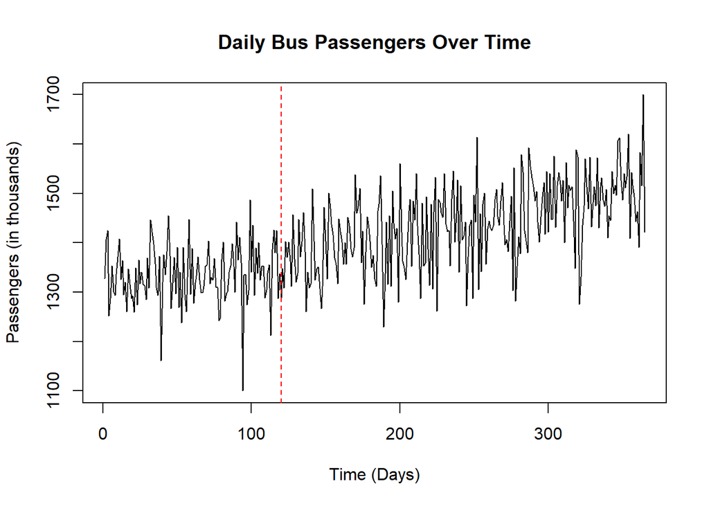

```r
plot(d$Time, d$Passengers, type='l', xlab='Time (Days)', ylab='Passengers (in thousands)', main='Daily Bus Passengers Over Time')
abline(v=120, col='red', lty=2) # Vertical line at
```

**Prior to the intervention, there appears to be a slight, but positive slope. This indicates there was a gradual increase in ridership happening before the intervention. After the intervention there does appear to be an improvement in ridership over time, but no discernible spikes at the time of treatment.**

### Question 2: The Naive Model

#### Q2a: Run the standard Interrupted Time Series model using OLS (lm) and print the results in a Stargazer table. (10 points)

````r
# Reminder: While completing your lab, set type = "text" for your stargazer(), but, remember to set type = "html" when you are ready to knit and submit your lab. You will also need to include in your code chunk header results =' asis' to properly render the table in the knitted HTML file. Your code chunk header should look like this: ```{r, results = 'asis'}

# Build your ITS Model
ITS <- lm(Passengers ~ Time + Treatment + TimeSince, data = d)

stargazer(ITS,
          type = "html",
          digits = 2,
          omit.stat = "all")
````

|  | *Dependent variable:* |
| --- | --- |
|  | Passengers |
| Time | 0.11 |
|  | (0.18) |
| Treatment | 22.19 |
|  | (15.11) |
| TimeSince | 0.50*** |
|  | (0.19) |
| Constant | 1,327.89*** |
|  | (12.42) |
| *Note:* | p<0.1; p<0.05; p<0.01 |

#### Q2b: Define and interpret the following coefficients, including their significance levels and their practical meaning in the context of our policy intervention: (5 points each)

> Note: Define what the coefficient represents, its value, significance level, and the meaning of the number in terms of our data context (e.g. a coefficient of 100 would be 100,000 passengers).

**Intercept ($b_0$): The intercept represents the average number of passengers when all other variables are equal to 0. In other words, the average number of passengers at the point in time prior to the start of our data was approximately $1,327$ thousand passengers ($1.33$ million passengers). This coefficient is statistically significant because it is different from $0$.**

**Time ($b_1$): The pre-intervention slope, or the average change in passengers for each additional day before the intervention. The coefficient of $0.11$ indicates that, on average, there was an increase of $0.11$ thousand passengers (or $110$ passengers) per day before the intervention. This coefficient is not statistically significant.**

**Treatment ($b_2$): The immediate effect of the intervention on the number of passengers. The coefficient of $22.19$ indicates that there was an immediate increase of $22.19$ thousand passengers (or $22,190$ passengers) on the day of the intervention (T=121). The Treatment coefficient was not statistically significant, suggesting the new bus schedule did not have an immediate effect on ridership.**

**TimeSince ($b_3$): The sustained effect of the intervention on the number of passengers. The coefficient of $0.50$ suggests that there was a statistically significant increase in the pre-intervention slope ($b_1$) by approximately $0.5$ thousand passengers per day (or $500$ passengers) after the new bus schedules. This demonstrates that the intervention had a sustained effect.**

### Question 3: Diagnostics & Robustness

#### Q3a: Test for Autocorrelation. Run a Durbin-Watson test (dwtest from lmtest package) and plot the Autocorrelation Function (acf) of your model residuals. Explain the output from both. Based on these two diagnostics, do we satisfy the assumption of independent errors? Is the level of autocorrelation what we would expect to see with time series data? (10 points)

```r
dwtest(ITS)
```

```
##
##  Durbin-Watson test
##
## data:  ITS
## DW = 2.0555, p-value = 0.6456
## alternative hypothesis: true autocorrelation is greater than 0
```

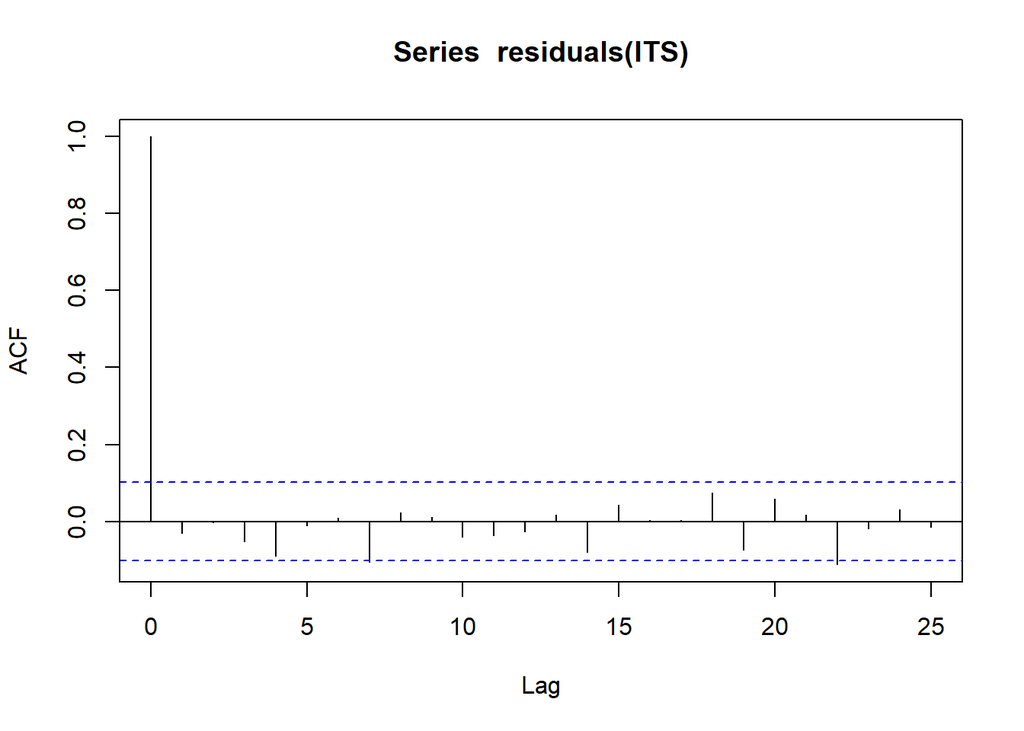

```r
acf(residuals(ITS))
```

**The Durbin-Watson test calculated a DW score of** ~$2$ **and a p-value of** $0.64$ **. These values indicate there is no significant autocorrelation within our data. Furthermore, our acf() showed significant autocorrelation at lag** $22$ **out of** $25$**. Given our Durbin-Watson test, we can comfortably say there is no significant autocorrelation present in our data and that we satisfy the requirement of independent errors. Finding no significant autocorrelation in time series data is highly abnormal. We would expect to see autocorrelation.**

#### Q3b: Re-estimate your model using Robust Standard Errors. Use the Newey-West function (from sandwich package) to calculate the robust standard errors. Then, use stargazer to display the Naive Model (from Q2) and the Robust Model side-by-side. (10 points)

````r
# Reminder: While completing your lab, set type = "text" for your stargazer(), but, remember to set type = "html" when you are ready to knit and submit your lab. You will also need to include in your code chunk header results =' asis' to properly render the table in the knitted HTML file. Your code chunk header should look like this: ```{r, results = 'asis'}

# Calculate Robust Standard Errors
robust_se <- sqrt(diag(NeweyWest(ITS)))

stargazer(ITS, ITS,
          se = list(NULL, robust_se),
          type = "html",
          digits = 2,
          omit.stat = "all",
          column.labels = c("Naive Model", "Robust Model"))
````

|  | *Dependent variable:* |  |
| --- | --- | --- |
|  | Passengers |  |
|  | Naive Model | Robust Model |
|  | (1) | (2) |
| Time | 0.11 | 0.11 |
|  | (0.18) | (0.11) |
| Treatment | 22.19 | 22.19** |
|  | (15.11) | (10.69) |
| TimeSince | 0.50*** | 0.50*** |
|  | (0.19) | (0.13) |
| Constant | 1,327.89*** | 1,327.89*** |
|  | (12.42) | (8.26) |
| *Note:* | p<0.1; p<0.05; p<0.01 |  |

#### Q3c: Compare the results. Did the statistical significance of your coefficients change after calculating robust standard errors? What does this imply for the Mayor’s policy? (5 points)

> Note: Robust standard errors ‘fix’ both autocorrelation AND heterskedasticity in our data. If autocorrelation DOES NOT exist and our significance levels change, it must have been due to heteroskedasticity, not autocorrelation.

**Yes, the statistical significance of the coefficients changed after calculating robust standard errors. In the naive model, the Treatment coefficient was not statistically significant, suggesting that the new bus schedule did not have an immediate effect on ridership. However, in the robust model, the Treatment coefficient became statistically significant at the 0.05 level. This implies that after accounting for autocorrelation (which did not exist in our data) AND heteroskedasticity (which must have existed in our data), we can conclude that the new bus schedule had a significant immediate effect on ridership. For the Mayor’s policy, this suggests that the intervention was effective in increasing bus ridership immediately after implementation.**

### Question 4: Counterfactual Analysis

#### Q4a: Print the actual number of passengers from the data at T = 150. What does this value represent? (5 points)

> Note: The actual value from the dataset, not the counterfactual

```r
d$Passengers[d$Time == 150]
```

```
## [1] 1403
```

**At Time = 150, ridership that day was** $1,403$ **thousand, or** $1.4$ **million passengers. This is the actual value from the dataset which is ridership after the intervention occurred.**

#### Q4b: Calculate the counterfactual number of passengers at T=150. What does this value represent? (5 points)

```r
# Hint: The predict() function often prints a row number with the result.
# You can use unname(predict(...)) to remove it for a cleaner output.

cf150 <- data.frame(
  Time = 150,
  Treatment = 0,
  TimeSince = 0
)

cf_150 <- unname(predict(ITS, newdata = cf150))

print(cf_150)
```

```
## [1] 1343.99
```

**The counterfactual at Time = 150 represents the predicted number of passengers had the new bus schedule not been released. Our model predicts that, had the intervention not occurred, we would have seen** $1, 344$ **thousand passengers, or** $1,344,000$ **passengers. Compared to the number of passengers at this time, it could be inferred that the new schedule increased ridership to the tune of** $59,000$ **passengers.**

#### Q4c: Calculate the counterfactual number of passengers at T=250. Why is the counterfactual from T=150 different from T=250? (5 points)

```r
# Hint: The predict() function often prints a row number with the result.
# You can use unname(predict(...)) to remove it for a cleaner output.

cf250 <- data.frame(
  Time = 250,
  Treatment = 0,
  TimeSince = 0
)

cf_250 <- unname(predict(ITS, newdata = cf250))

print(cf_250)
```

```
## [1] 1354.723
```

**The counterfactual at Time = 250 represents the predicted number of passengers had the new bus schedule not been released. Our model predicts that, had the intervention not occurred, we would have seen** $1354.72$ **thousand passengers, or** $1,354,720$ **passengers that day. Although both counterfactuals represent what would have happened had the intervention not occurred, the key difference is that each counterfactual varies depending on the specific point in time. The Time coefficient represents the pre-intervention trend, which the counterfactual would follow. As that slope changes, so does the counterfactual for every point in time. The difference between the two is simply the point in time and where on the pre-intervention slope it lands.**

#### Q4d: What is the difference between the actual number of passengers at T=150 and the counterfactual from the same time? In the context of the policy, what does this difference represent? (5 points)

```r
round(d$Passengers[d$Time == 150] - cf_150, 0)
```

```
## [1] 59
```

**At Time = 150, the counterfactual ridership would have been** $1,344,000$ **while the actual ridership was** $1,403,000$**. Representing a difference in passengers to the tune of** $59,000$ **more passengers due to the new schedule.**

### Bonus: Control Groups (10 points)

We have learned that there are threats to the validity of time series analysis. In particular, another event might have occurred at the same time of the intervention and caused the immediate and sustained effect that we observe.

A way to address this issue is to use a control group that is not subject to the intervention. This design makes sure that the effect we observe is the result of the policy intervention.

The mayor proposes to utilize city B as a control group. City B is a neighbor city with very similar characteristics to city A. Yet city B has not changed its bus schedule in the past year.

#### BQ1: Upload the data TS_Groups_Lab.csv from the URL provided below. Estimate a new time series model that includes the control group (Equation 4.1 in your lecture). (5 points)

```r
# Loads in Data for Bonus Questions
URL <- "https://raw.githubusercontent.com/DS4PS/pe4ps-textbook/master/labs/DATA/TS_Groups_lab.csv"

# This step simply removes an unnecessary column (X) from the dataframe and renames the passengers column to Passengers
dat.grouped <- read.csv( URL, stringsAsFactors=F) %>% select(passengers, Time, Treatment, TimeSince, Group) %>%  rename(Passengers = passengers)

# Preview the data
rbind(head(dat.grouped, 5), tail(dat.grouped, 5))
```

```
##     Passengers Time Treatment TimeSince Group
## 1     1175.085    1         0         0     1
## 2     1145.686    2         0         0     1
## 3     1163.903    3         0         0     1
## 4     1159.379    4         0         0     1
## 5     1132.647    5         0         0     1
## 726   1195.547  361         1       241     0
## 727   1251.900  362         1       242     0
## 728   1237.931  363         1       243     0
## 729   1253.600  364         1       244     0
## 730   1226.645  365         1       245     0
```

````r
# Reminder: While completing your lab, set type = "text" for your stargazer(), but, remember to set type = "html" when you are ready to knit and submit your lab. You will also need to include in your code chunk header results =' asis' to properly render the table in the knitted HTML file. Your code chunk header should look like this: ```{r, results = 'asis'}

  # Build your ITS w/ Control Group Model
    # Group:Time == Group * Time
ITS_Group <- lm(Passengers ~ Time + Treatment + TimeSince + Group + Group:Time + Group:Treatment + Group:TimeSince, data = dat.grouped)

  # Print the results with stargazer
stargazer(ITS_Group,
          type = "html",
          digits = 2)
````

|  | *Dependent variable:* |
| --- | --- |
|  | Passengers |
| Time | 0.11 |
|  | (0.07) |
| Treatment | -5.72 |
|  | (5.51) |
| TimeSince | 0.15** |
|  | (0.07) |
| Group | -30.63*** |
|  | (6.45) |
| Time:Group | 0.47*** |
|  | (0.09) |
| Treatment:Group | 7.75 |
|  | (7.80) |
| TimeSince:Group | 1.16*** |
|  | (0.10) |
| Constant | 1,171.88*** |
|  | (4.56) |
| Observations | 730 |
| R<sup>2</sup> | 0.97 |
| Adjusted R<sup>2</sup> | 0.97 |
| Residual Std. Error | 24.81 (df = 722) |
| F Statistic | 3,451.29*** (df = 7; 722) |
| *Note:* | p<0.1; p<0.05; p<0.01 |

#### BQ2: Interpret the Treatment * Group coefficient. Is it statistically significant? (5 points)

**The Treatment:Group coefficient is** $7.75$ **and is not statistically significant. This coefficient represents the difference between the treatment and control group at the point of intervention and represents the immediate effect between the two groups. This suggests, although not statistically significant, that the treatment group experienced an increase in ridership to the tune of** $7.75$ **thousand, or,** $7,750$ **more passengers in addition to the increase experienced by the control group.**

## Submission Instructions

When you have completed your assignment, knit your RMD file to generate your rendered HTML file.

1. Login to Canvas at http://canvas.asu.edu and navigate to the assignments tab in the course repository.
2. Upload your HTML and RMD files to the appropriate lab submission link.

**Remember to:**

- Include your name as the author in the YAML header.
- Name your files according to the convention: `Lab-##-LastName.Rmd`.
- Show your solution and include your code.
- Format your regression tables using `stargazer`.
- **Bold your answers.**
- Do **NOT** print excessive output (like a full data set).
- Follow appropriate style guidelines (spaces between arguments, etc.).

*Note: Canvas sometimes disallows HTML file submissions when there is embedded computer code. If this happens, create a zipped folder with both the RMD and HTML files.*

[output not shown]